# Homework No 1

UTRGV School of Mathematical and Statistical Sciences

STAT 3301 Applied Statistics

(Samuel Lee)

> **Objective:** Use the R notebook to present homework reports in a standard and organized manner.
- Read Chapters No 1 and No 2 of Book: R Cookbook, 2nd Edition by Paul Teetor ISBN-10: 1492040681 https://rc2e.com/
- Review the documentation for the function `seq`. Use the `seq` function in R to create a numeric vector with 150 values ranging from $0$ to $2\pi.$ Hint: check the parameter `length.out` in the `seq` function. Assign your result to a variable named `t`.
- Compute the sine of `t` using the function `sin`. Assign your result to variable `fs.`
- What is the proportion of values in `fs` that are strictly greater than 0?
- What is the mean of `fs`?
- Create a vector named `fs2` that corresponds with the square of `fs`.
- Create a Boolean vector named `idx` with entries `TRUE` where `fs2>0.3`, an FALSE otherwise.
- What is the mean of `fs` considering only entries with `fs2>0.3`? Hint: use `idx`
- Use `plot` function to plot `fs` vs `t`
- Improve the graphics according to your taste. Eg., look the documentation for `plot`, use parameters like `type`, `col`, `lwd`, etc. Include title (using `main`), `xlab` and `ylab`.

Start your homework here:

this is how we create t:

```r
t <- seq(1, 2 * pi, length.out = 150)
print(t)
```

```
  [1] 1.000000 1.035458 1.070915 1.106373 1.141830 1.177288 1.212746 1.248203 1.283661 1.319119 1.354576
 [12] 1.390034 1.425491 1.460949 1.496407 1.531864 1.567322 1.602780 1.638237 1.673695 1.709152 1.744610
 [23] 1.780068 1.815525 1.850983 1.886440 1.921898 1.957356 1.992813 2.028271 2.063729 2.099186 2.134644
 [34] 2.170101 2.205559 2.241017 2.276474 2.311932 2.347390 2.382847 2.418305 2.453762 2.489220 2.524678
 [45] 2.560135 2.595593 2.631050 2.666508 2.701966 2.737423 2.772881 2.808339 2.843796 2.879254 2.914711
 [56] 2.950169 2.985627 3.021084 3.056542 3.092000 3.127457 3.162915 3.198372 3.233830 3.269288 3.304745
 [67] 3.340203 3.375661 3.411118 3.446576 3.482033 3.517491 3.552949 3.588406 3.623864 3.659321 3.694779
 [78] 3.730237 3.765694 3.801152 3.836610 3.872067 3.907525 3.942982 3.978440 4.013898 4.049355 4.084813
 [89] 4.120271 4.155728 4.191186 4.226643 4.262101 4.297559 4.333016 4.368474 4.403931 4.439389 4.474847
[100] 4.510304 4.545762 4.581220 4.616677 4.652135 4.687592 4.723050 4.758508 4.793965 4.829423 4.864881
[111] 4.900338 4.935796 4.971253 5.006711 5.042169 5.077626 5.113084 5.148541 5.183999 5.219457 5.254914
[122] 5.290372 5.325830 5.361287 5.396745 5.432202 5.467660 5.503118 5.538575 5.574033 5.609491 5.644948
[133] 5.680406 5.715863 5.751321 5.786779 5.822236 5.857694 5.893151 5.928609 5.964067 5.999524 6.034982
[144] 6.070440 6.105897 6.141355 6.176812 6.212270 6.247728 6.283185
```

this is how we create fs:

```r
fs <- sin(t)
print(fs)
```

```
  [1]  8.414710e-01  8.600959e-01  8.776396e-01  8.940799e-01  9.093964e-01  9.235696e-01  9.365818e-01
  [8]  9.484166e-01  9.590591e-01  9.684960e-01  9.767154e-01  9.837069e-01  9.894618e-01  9.939729e-01
 [15]  9.972344e-01  9.992422e-01  9.999940e-01  9.994886e-01  9.977267e-01  9.947106e-01  9.904441e-01
 [22]  9.849324e-01  9.781826e-01  9.702030e-01  9.610039e-01  9.505966e-01  9.389943e-01  9.262117e-01
 [29]  9.122646e-01  8.971708e-01  8.809491e-01  8.636199e-01  8.452051e-01  8.257278e-01  8.052124e-01
 [36]  7.836848e-01  7.611720e-01  7.377024e-01  7.133053e-01  6.880116e-01  6.618529e-01  6.348623e-01
 [43]  6.070735e-01  5.785216e-01  5.492424e-01  5.192728e-01  4.886503e-01  4.574136e-01  4.256019e-01
 [50]  3.932551e-01  3.604140e-01  3.271198e-01  2.934143e-01  2.593401e-01  2.249397e-01  1.902567e-01
 [57]  1.553344e-01  1.202169e-01  8.494822e-02  4.957278e-02  1.413501e-02 -2.132052e-02 -5.674925e-02
 [64] -9.210664e-02 -1.273482e-01 -1.624298e-01 -1.973071e-01 -2.319364e-01 -2.662741e-01 -3.002770e-01
 [71] -3.339025e-01 -3.671083e-01 -3.998525e-01 -4.320941e-01 -4.637925e-01 -4.949079e-01 -5.254011e-01
 [78] -5.552338e-01 -5.843685e-01 -6.127686e-01 -6.403984e-01 -6.672232e-01 -6.932091e-01 -7.183237e-01
 [85] -7.425352e-01 -7.658132e-01 -7.881286e-01 -8.094532e-01 -8.297602e-01 -8.490241e-01 -8.672207e-01
 [92] -8.843271e-01 -9.003218e-01 -9.151847e-01 -9.288971e-01 -9.414418e-01 -9.528030e-01 -9.629664e-01
 [99] -9.719192e-01 -9.796503e-01 -9.861498e-01 -9.914096e-01 -9.954231e-01 -9.981853e-01 -9.996926e-01
[106] -9.999432e-01 -9.989367e-01 -9.966745e-01 -9.931593e-01 -9.883957e-01 -9.823895e-01 -9.751483e-01
[113] -9.666813e-01 -9.569990e-01 -9.461137e-01 -9.340390e-01 -9.207902e-01 -9.063838e-01 -8.908379e-01
[120] -8.741722e-01 -8.564076e-01 -8.375663e-01 -8.176722e-01 -7.967501e-01 -7.748264e-01 -7.519287e-01
[127] -7.280857e-01 -7.033275e-01 -6.776851e-01 -6.511907e-01 -6.238778e-01 -5.957805e-01 -5.669343e-01
[134] -5.373754e-01 -5.071410e-01 -4.762690e-01 -4.447983e-01 -4.127684e-01 -3.802197e-01 -3.471930e-01
[141] -3.137298e-01 -2.798722e-01 -2.456628e-01 -2.111445e-01 -1.763608e-01 -1.413554e-01 -1.061724e-01
[148] -7.085582e-02 -3.545019e-02 -2.449213e-16
```

```r
length(fs[fs>0])
```

```
[1] 61
```

```r
61/150
```

```
[1] 0.4066667
```

According to length function, fs has 61 elements that are greater than 0. So 40.67% of elements are greater than 0.

```r
mean(fs)
```

```
[1] -0.08361743
```

According to mean function, -0.08361743 is the mean of fs.

This is how we create fs2:

```r
fs2 <- fs ^ 2
print(fs2)
```

```
  [1] 7.080734e-01 7.397649e-01 7.702512e-01 7.993790e-01 8.270018e-01 8.529808e-01 8.771854e-01 8.994940e-01
  [9] 9.197943e-01 9.379845e-01 9.539729e-01 9.676793e-01 9.790347e-01 9.879820e-01 9.944764e-01 9.984851e-01
 [17] 9.999879e-01 9.989774e-01 9.954586e-01 9.894492e-01 9.809794e-01 9.700918e-01 9.568411e-01 9.412939e-01
 [25] 9.235284e-01 9.036339e-01 8.817104e-01 8.578680e-01 8.322267e-01 8.049154e-01 7.760713e-01 7.458394e-01
 [33] 7.143717e-01 6.818264e-01 6.483670e-01 6.141619e-01 5.793829e-01 5.442048e-01 5.088045e-01 4.733599e-01
 [41] 4.380493e-01 4.030501e-01 3.685383e-01 3.346872e-01 3.016672e-01 2.696442e-01 2.387792e-01 2.092272e-01
 [49] 1.811370e-01 1.546496e-01 1.298982e-01 1.070074e-01 8.609198e-02 6.725727e-02 5.059789e-02 3.619760e-02
 [57] 2.412878e-02 1.445210e-02 7.216200e-03 2.457460e-03 1.997986e-04 4.545646e-04 3.220478e-03 8.483634e-03
 [65] 1.621758e-02 2.638343e-02 3.893008e-02 5.379447e-02 7.090188e-02 9.016631e-02 1.114909e-01 1.347685e-01
 [73] 1.598820e-01 1.867053e-01 2.151035e-01 2.449338e-01 2.760463e-01 3.082846e-01 3.414866e-01 3.754854e-01
 [81] 4.101101e-01 4.451868e-01 4.805389e-01 5.159889e-01 5.513585e-01 5.864699e-01 6.211467e-01 6.552144e-01
 [89] 6.885020e-01 7.208419e-01 7.520717e-01 7.820344e-01 8.105793e-01 8.375630e-01 8.628498e-01 8.863127e-01
 [97] 9.078335e-01 9.273043e-01 9.446270e-01 9.597147e-01 9.724914e-01 9.828930e-01 9.908672e-01 9.963738e-01
[105] 9.993853e-01 9.998863e-01 9.978746e-01 9.933601e-01 9.863655e-01 9.769260e-01 9.650891e-01 9.509143e-01
[113] 9.344727e-01 9.158472e-01 8.951312e-01 8.724289e-01 8.478545e-01 8.215315e-01 7.935922e-01 7.641771e-01
[121] 7.334339e-01 7.015173e-01 6.685878e-01 6.348107e-01 6.003560e-01 5.653968e-01 5.301089e-01 4.946696e-01
[129] 4.592571e-01 4.240494e-01 3.892235e-01 3.549545e-01 3.214145e-01 2.887724e-01 2.571920e-01 2.268322e-01
[137] 1.978455e-01 1.703778e-01 1.445670e-01 1.205429e-01 9.842636e-02 7.832843e-02 6.035019e-02 4.458200e-02
[145] 3.110314e-02 1.998136e-02 1.127257e-02 5.020547e-03 1.256716e-03 5.998643e-32
```

This is how we create idx:

```r
idx <- fs2 > 0.3
print(idx)
```

```
  [1]  TRUE  TRUE  TRUE  TRUE  TRUE  TRUE  TRUE  TRUE  TRUE  TRUE  TRUE  TRUE  TRUE  TRUE  TRUE  TRUE  TRUE
 [18]  TRUE  TRUE  TRUE  TRUE  TRUE  TRUE  TRUE  TRUE  TRUE  TRUE  TRUE  TRUE  TRUE  TRUE  TRUE  TRUE  TRUE
 [35]  TRUE  TRUE  TRUE  TRUE  TRUE  TRUE  TRUE  TRUE  TRUE  TRUE  TRUE FALSE FALSE FALSE FALSE FALSE FALSE
 [52] FALSE FALSE FALSE FALSE FALSE FALSE FALSE FALSE FALSE FALSE FALSE FALSE FALSE FALSE FALSE FALSE FALSE
 [69] FALSE FALSE FALSE FALSE FALSE FALSE FALSE FALSE FALSE  TRUE  TRUE  TRUE  TRUE  TRUE  TRUE  TRUE  TRUE
 [86]  TRUE  TRUE  TRUE  TRUE  TRUE  TRUE  TRUE  TRUE  TRUE  TRUE  TRUE  TRUE  TRUE  TRUE  TRUE  TRUE  TRUE
[103]  TRUE  TRUE  TRUE  TRUE  TRUE  TRUE  TRUE  TRUE  TRUE  TRUE  TRUE  TRUE  TRUE  TRUE  TRUE  TRUE  TRUE
[120]  TRUE  TRUE  TRUE  TRUE  TRUE  TRUE  TRUE  TRUE  TRUE  TRUE  TRUE  TRUE  TRUE  TRUE FALSE FALSE FALSE
[137] FALSE FALSE FALSE FALSE FALSE FALSE FALSE FALSE FALSE FALSE FALSE FALSE FALSE FALSE
```

```r
mean <- 0
for (x in idx){
for (y in fs){
    if (x==TRUE)
  {
    mean <- mean + y
  }
}
}
print(mean)
```

```
[1] -1266.804
```

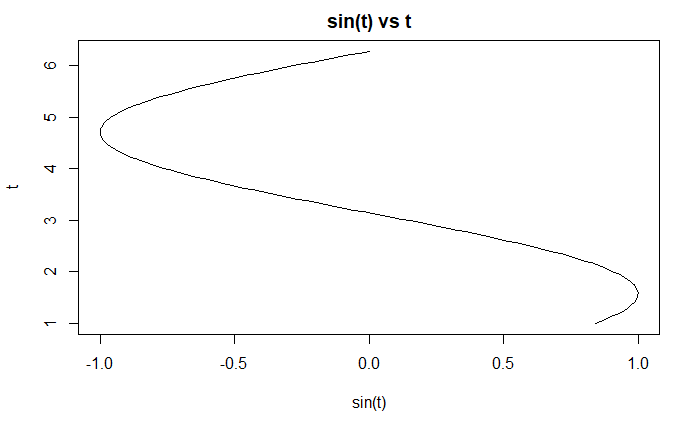

```r
plot(fs,t, main = "sin(t) vs t", xlab = "sin(t)", ylab = "t", type = "l")
```